# Visual Story on Youtube ad behaviour

## Introduction to the Data

In this digital age, the content we consume is fueled by advertisements. This visual story explores a dataset of YouTube advertisements logged during various viewing sessions. By doing this I aim to uncover how ad duration, placement, and category interact with the videos we watch.

The data includes timestamps, device types, video popularity metrics and more allowing us to see exactly how the YouTube algorithm targets its audience.

## My Youtube Watching Routine

This visualisation was more of an indicator for myself to see my Youtube watch behaviour. This also can potentially telling us whether ads are more likely to appear at certain times.

This heatmap suggests that certain hours see a significant spike in ad delivery, likely aligning with peak user engagement times across different time zones.

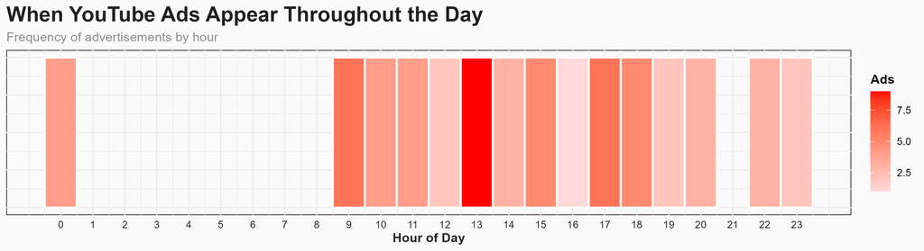

Heatmap graph showing how often ads are appearing throughout the day

We can see in this visualisation that Youtube gave me the most ads around 1pm. This could be because they know people are watching Youtube while they are eating lunch (Like I do) or just that I am watching the most Youtube during this time. We can also see a period from 1am to 8am with no ads which makes sense as I was asleep during this time.

## The Duration Dilemma

How much of your time do these ads actually take? This visualisation looks at whether the type of an ad affects how long it is.

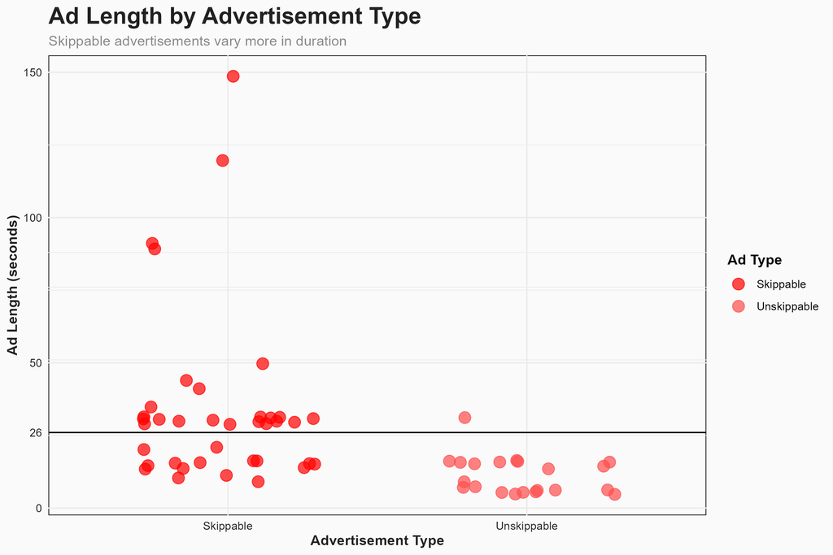

## Content Alignment

Advertisers don’t just pick videos at random, they target specific video categories. By looking at the intersection of video themes and ad categories, we can see wherther different ads appear more depending on the video category.

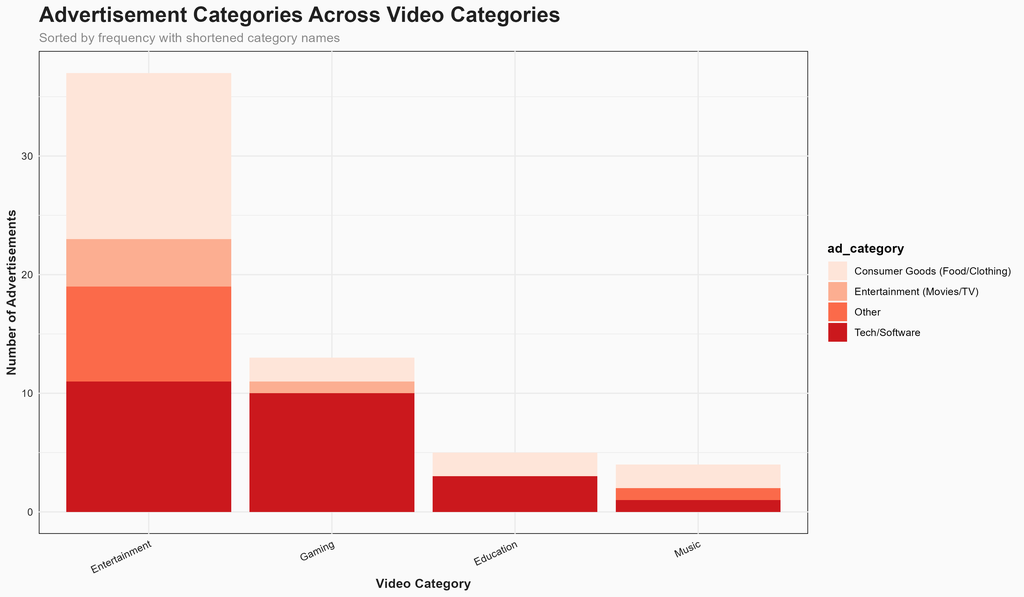

Stacked Bar graph showing the number of differen ad types that appear based on video types

We can see in this visualisation that I mainly watch entertainment so majority of the ads appear there. Something interesting we see is that most entertainment ads appear during entertainment videos.

## Popularity and Placement

Does a video with 10 million views treat ads differently than a small creator’s video? In this visualisation I analyzed the Ad Location (Pre-roll vs Mid-roll) relative to the video’s total view count.

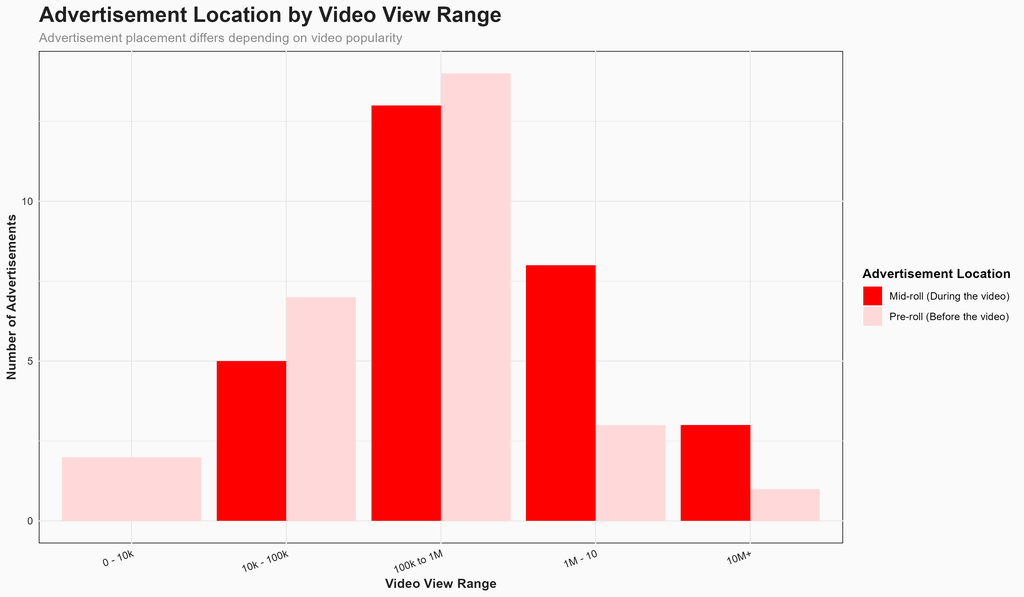

Bar Graph showing the relationship between advertisement location and video views

The data shows a bell curve where the number of ads increase as we approach the 100k to 1M view catergory and then decrease again. For most of the views categories there fairly equal proportion of pre-roll and mid-roll ads however for the 1M to 10M view category there is a significantly higher proportion of mid-roll ads.

## Device-Based Delivery

Finally, we look at the hardware. Does watching on a Mobile device result in different ad lengths compared to a Smart TV?

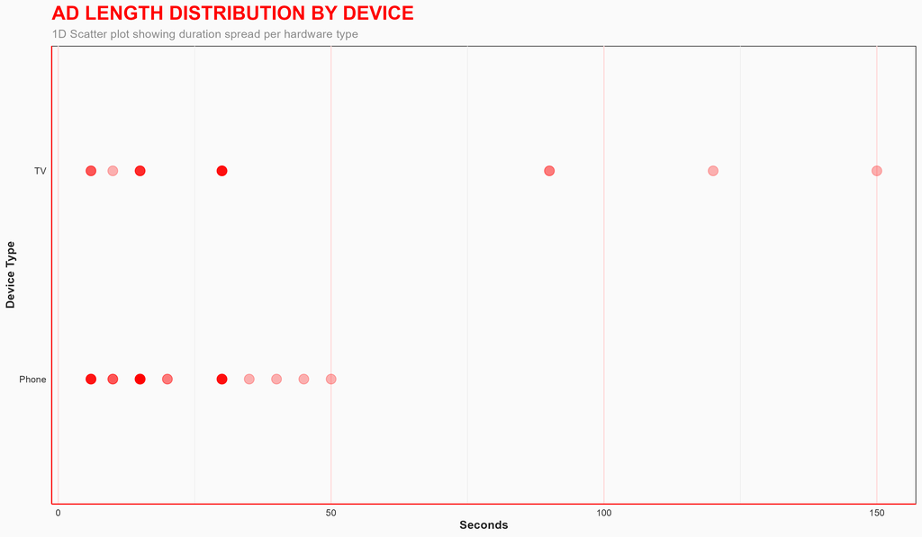

Dot plot graph showing the relationship between ad length and device type

The distribution shows us that ads on mobile devices are consistantly between 6 to 50 seconds. However we see for TV ads we are more likely to get longer ads over the 1 minute mark.

## Conclusion

This visual journey through the data highlights the complexity of the YouTube advertising. From the precise timing of delivery to the strategic placement in high-traffic videos, every ad is a data point in a larger algorithmic story.